# Example 3.3: Navarre weather stations. Co-kriging of maximum temperature

Author

Aritz Adin and Tomás Goicoa

Published

Dec/2026

# 1 Objectives

In this example we will:

- Predict the **maximum temperature** (primary variable) in Navarre on 6 February 2010 using the **minimum temperature** (secondary variable) recorded at the same weather stations.
- Compare **ordinary kriging** and **ordinary co-kriging** using prediction maps, their standard errors and cross-validation.
- Learn how to compare both methods **fairly**.

**TipR script**

You can download the R script with all the code of this example and follow it step by step in RStudio:

# 2 Packages

```r
library(dplyr)
library(gstat)
library(mapSpain)
library(sf)
library(tmap)
```

The `mapSpain` package provides the administrative boundaries of Spain (autonomous communities, provinces, municipalities…) as `sf` objects, so no additional files are needed to draw the maps.

# 3 Description of the data

The data contain the daily records of 84 manual weather stations in Navarre on 6 February 2010. The file can be read directly from the course website:

```r
stations <- read.csv("https://raw.githubusercontent.com/aritz-adin/MUSIGT_2026-27/main/data/manual_20100206.csv",
                     colClasses = c(CODE = "character"))
head(stations)
```

```
  CODE         STATION DISTRICT      X       Y   Z TMAX TMIN PRECIP DAY MONTH YEAR
1 1001    Zugarramurdi        1 617807 4794407 137 12.8  5.2    4.1   6     2 2010
2 1032          Leitza        1 590766 4771412 668  7.0  3.0   16.0   6     2 2010
3 1688          Tudela        7 615164 4657089 300 14.0  2.5    0.0   6     2 2010
4 0025     Santesteban        1 608685 4776273 131 13.0  5.0   10.0   6     2 2010
5 2505 Esparza Salazar        2 655483 4746727 695  7.0  0.0    7.3   6     2 2010
6 2604         Irurita        1 618607 4777123 183 11.0  3.0    5.6   6     2 2010
```

| Column | Meaning |
| --- | --- |
| `CODE`, `STATION` | Code and name of the station |
| `X`, `Y` | Coordinates (ETRS89 / UTM zone 30N, EPSG:25830), in metres |
| `Z` | Altitude (m) |
| `TMAX`, `TMIN` | Maximum and minimum temperature (ºC) |
| `PRECIP` | Precipitation (mm) |

```r
stations_sf <- stations |>
  st_as_sf(coords=c("X","Y"), crs=25830)
```

## Boundary of Navarre and prediction grid

We obtain the boundary of Navarre with the function `esp_get_prov()` and transform it to the same coordinate reference system as the stations:

```r
Navarra <- esp_get_prov(prov = "Navarra") |>
  st_transform(crs = 25830)
```

The prediction grid is a regular grid of points every **1 km** covering Navarre. The function `st_make_grid()` creates the grid over the bounding box of the boundary, and `st_filter()` keeps only the points inside Navarre:

```r
grid_sf <- st_make_grid(Navarra, cellsize = 1000, what = "centers") |>
  st_as_sf() |>
  st_filter(Navarra)

nrow(grid_sf)
```

```
[1] 10381
```

We can check the result by drawing the boundary of Navarre, the nodes of the prediction grid and the weather stations:

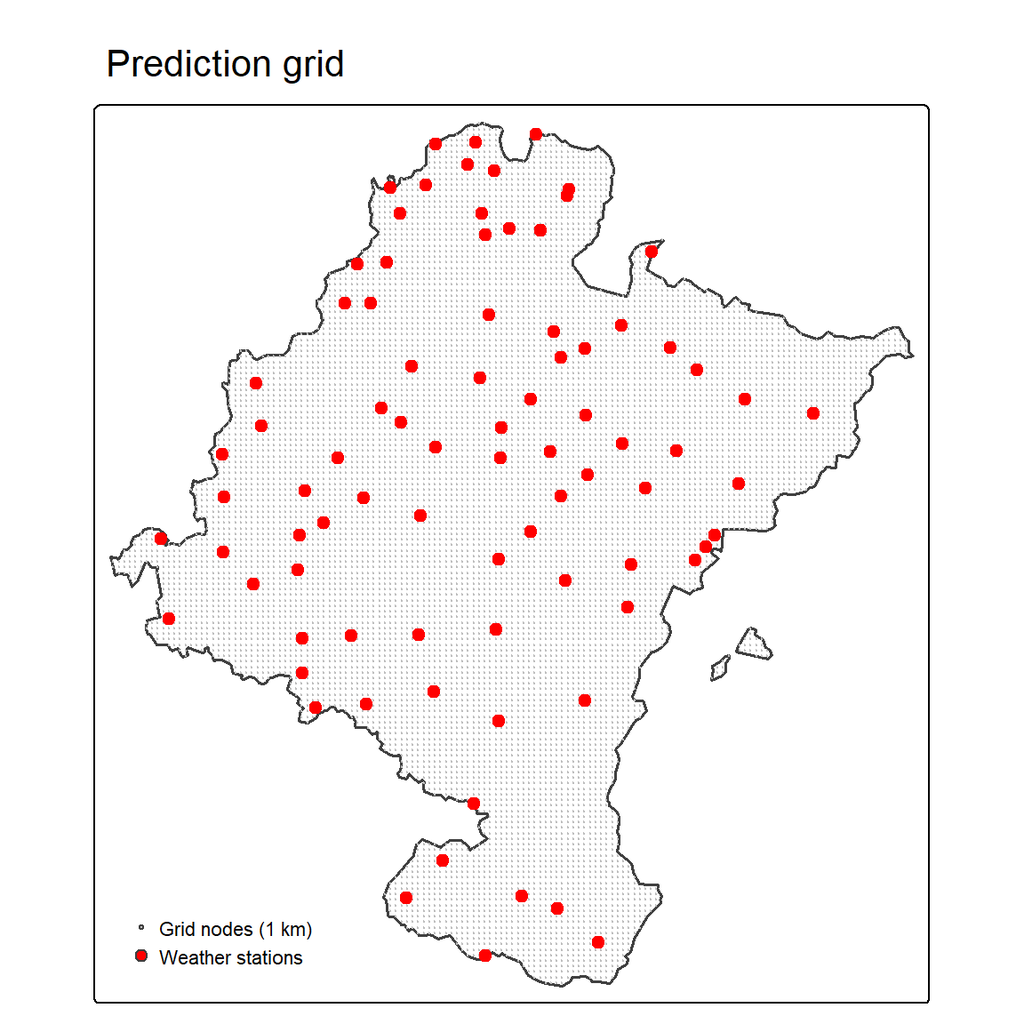

```r
tmap_mode("plot")

tm_shape(Navarra) + tm_borders(lwd=1.5) +
  tm_shape(grid_sf) + tm_dots(fill="grey", size=0.02) +
  tm_shape(stations_sf) + tm_dots(fill="red", size=0.5) +
  tm_add_legend(type = "symbols",
                labels = c("Grid nodes (1 km)", "Weather stations"),
                fill = c("grey", "red"),
                size = c(0.2, 0.5)) +
  tm_title("Prediction grid") +
  tm_layout(legend.position = c("left", "bottom"))
```

- Each `tm_shape()` adds a new layer on top of the previous ones: first the boundary of Navarre, then the grid nodes and finally the stations.

The prediction grid covers the whole territory, while the stations are irregularly distributed: there are more stations in the north and fewer in the south and in the Pyrenees (north-east).

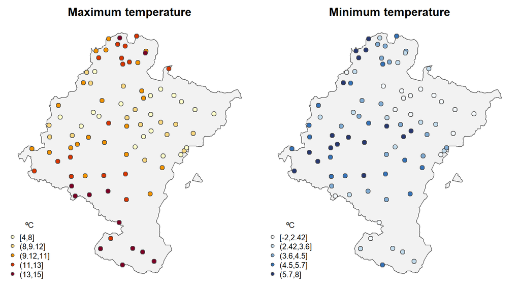

Maximum and minimum temperatures (ºC) recorded at the weather stations on 6 February 2010, classified by quintiles.

## Relationship between both variables

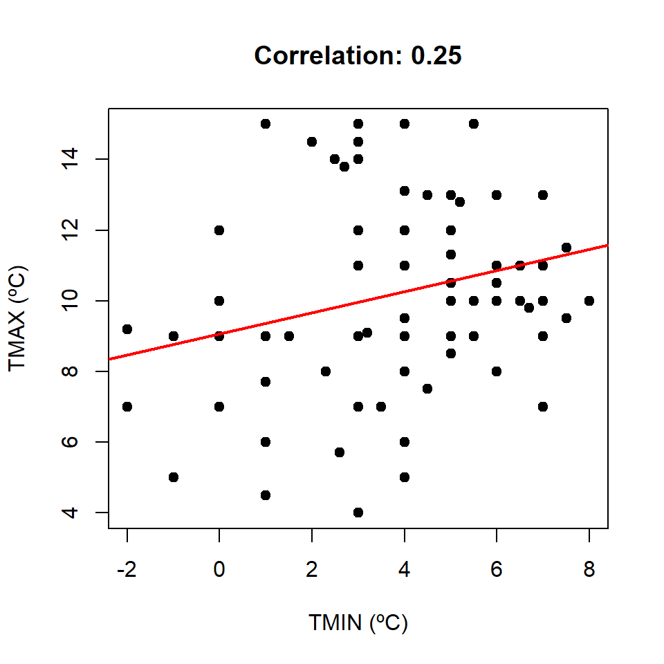

```r
r <- cor(stations$TMAX, stations$TMIN)

plot(stations$TMIN, stations$TMAX, pch = 19,
     xlab = "TMIN (ºC)", ylab = "TMAX (ºC)",
     main = paste("Correlation:", round(r, 2)))
abline(lm(TMAX ~ TMIN, data = stations), col = "red", lwd = 2)
```

**NoteInterpretation**

The correlation between the maximum and minimum temperatures is **weak** (0.25). Moreover, both variables have been measured at the **same stations**. According to Example 3.2 and its exercise, we should not expect a large improvement from co-kriging in this situation.

Both temperatures have approximately symmetric distributions, so we will work on the original scale (ºC).

# 4 Semivariogram of the primary variable

```r
v_tmax <- variogram(TMAX ~ 1, stations_sf, width = 10000)
v_tmax
```

```
   np      dist    gamma dir.hor dir.ver   id
1  79  7353.375 2.214620       0       0 var1
2 261 15554.248 2.904866       0       0 var1
3 359 25235.947 4.505125       0       0 var1
4 416 35182.561 5.786022       0       0 var1
5 441 44827.924 6.960295       0       0 var1
6 445 54881.331 8.253573       0       0 var1
7 138 61612.372 7.383261       0       0 var1
```

The argument `width = 10000` groups the pairs of stations into distance lags of 10 km. With only 84 stations, the default lags (`cutoff/15`, about 4 km) contain few pairs and the empirical semivariogram is quite noisy.

```r
vgm_tmax <- fit.variogram(v_tmax, model=vgm(psill=6, model="Sph",
                                            range=50000, nugget=1))
vgm_tmax
```

```
  model     psill    range
1   Nug  1.110432      0.0
2   Sph 11.228098 126421.1
```

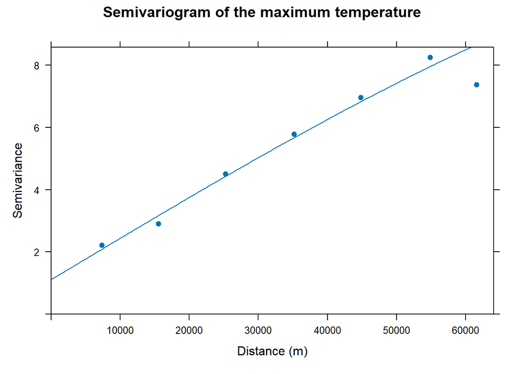

```r
plot(v_tmax, vgm_tmax, pch = 19,
     xlab = "Distance (m)", ylab = "Semivariance",
     main = "Semivariogram of the maximum temperature")
```

**NoteInterpretation of the fitted model**

- Nugget effect $\approx$ 1.11 and partial sill $\approx$ 11.23.
- The empirical semivariogram **does not level off** within the maximum distance considered, so the fitted range (126 km) is larger than the largest distance between pairs used to fit it. This usually indicates a **large-scale trend**: the maximum temperature increases towards the south of Navarre (see the map above). We come back to this issue in Section 8.

# 5 Ordinary kriging (TMAX only) and co-kriging (TMAX and TMIN)

```r
pred_krig <- krige(TMAX ~ 1, stations_sf, grid_sf, model=vgm_tmax)
```

```
[using ordinary kriging]
```

## 5.1 Linear model of coregionalization

```r
g <- gstat(NULL, id = "TMAX", formula = TMAX ~ 1, data = stations_sf)
g <- gstat(g,    id = "TMIN", formula = TMIN ~ 1, data = stations_sf)

v <- variogram(g, width = 10000)
lmc <- fit.lmc(v, g, model=vgm_tmax)
lmc$model
```

```
$TMAX
  model     psill    range
1   Nug  1.110432      0.0
2   Sph 11.228098 126421.1

$TMAX.TMIN
  model       psill    range
1   Nug 0.001538718      0.0
2   Sph 3.755327411 126421.1

$TMIN
  model    psill    range
1   Nug 1.435239      0.0
2   Sph 9.405934 126421.1
```

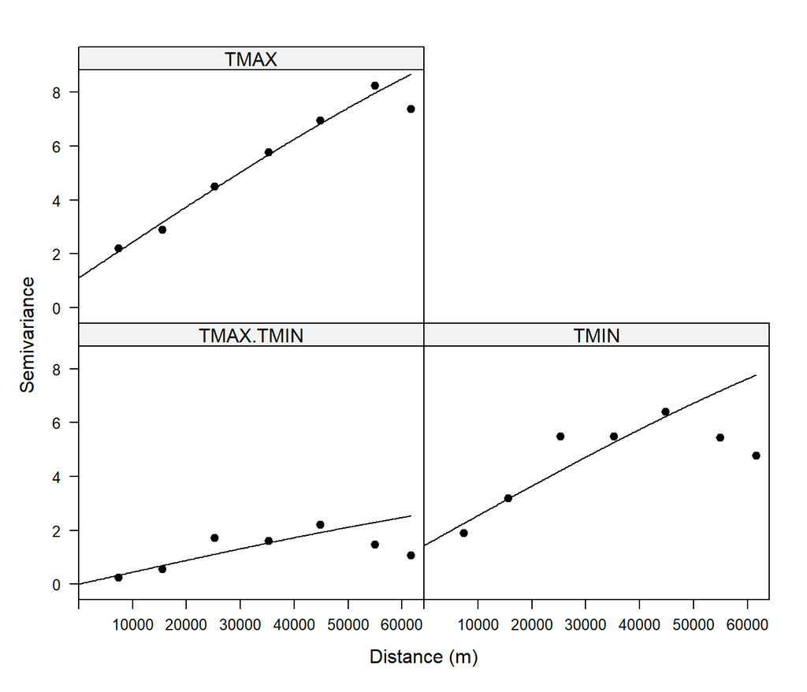

Direct and cross empirical semivariograms of the maximum (TMAX) and minimum (TMIN) temperatures, with the fitted linear model of coregionalization.

```r
plot(v, lmc, pch = 19, col = "black",
     xlab = "Distance (m)", ylab = "Semivariance",
     scales = list(alternating = 1, tck = c(1, 0)))
```

**NoteInterpretation**

The cross-semivariogram shows some spatial structure, but its sill (3.76) is much smaller than the sills of the direct semivariograms (12.34 and 10.84): the spatial correlation between both temperatures is weak.

## 5.2 Co-kriging predictions

```r
pred_cokrig <- predict(lmc, grid_sf, debug.level=0)
```

# 6 Comparison of the predictions

To draw the predictions as a continuous surface, each point of the grid is converted into a square cell of 1 km × 1 km:

```r
pred_sf <- grid_sf |>
  mutate(krig_pred   = pred_krig$var1.pred,
         krig_sd     = sqrt(pred_krig$var1.var),
         cokrig_pred = pred_cokrig$TMAX.pred,
         cokrig_sd   = sqrt(pred_cokrig$TMAX.var)) |>
  st_buffer(dist=500, endCapStyle="SQUARE")
```

## Predictions

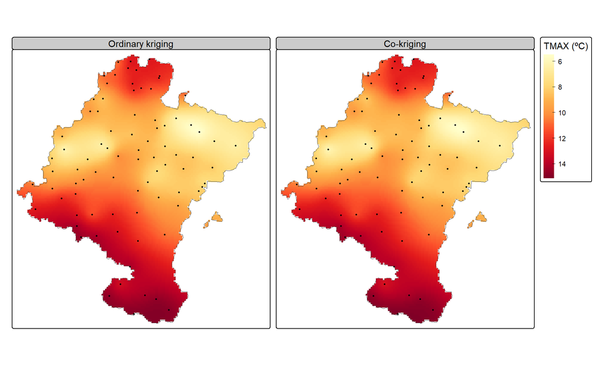

```r
tm_shape(pred_sf) +
  tm_polygons(fill = c("krig_pred", "cokrig_pred"),
              fill.scale  = tm_scale_continuous(values = "brewer.yl_or_rd"),
              fill.legend = tm_legend(title = "TMAX (ºC)"),
              fill.free = FALSE,    # common colour scale
              col = NULL) +         # no cell borders
  tm_facets_wrap(nrow=1) +
  tm_shape(Navarra) + tm_borders() +
  tm_shape(stations_sf) + tm_dots(fill="black", size=0.2) +
  tm_layout(panel.labels = c("Ordinary kriging", "Co-kriging"))
```

## Standard errors

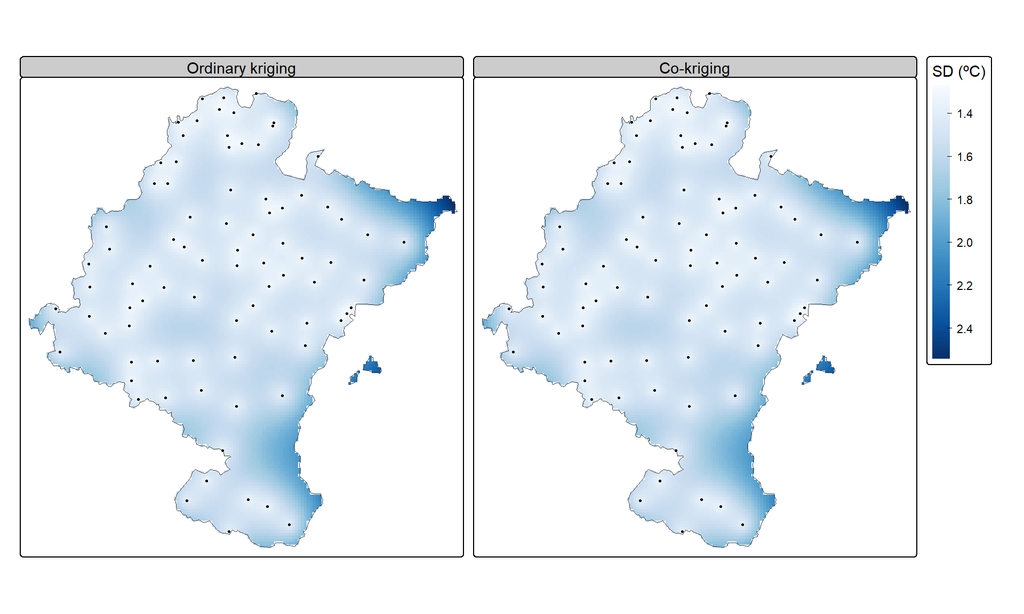

```r
tm_shape(pred_sf) +
  tm_polygons(fill = c("krig_sd", "cokrig_sd"),
              fill.scale  = tm_scale_continuous(values = "brewer.blues"),
              fill.legend = tm_legend(title = "SD (ºC)"),
              fill.free = FALSE,
              col = NULL) +
  tm_facets_wrap(nrow=1) +
  tm_shape(Navarra) + tm_borders() +
  tm_shape(stations_sf) + tm_dots(fill="black", size=0.2) +
  tm_layout(panel.labels = c("Ordinary kriging", "Co-kriging"))
```

**NoteInterpretation**

- Both prediction maps are almost identical: higher maximum temperatures in the south (Ribera) and in the low valleys of the far north, and lower in the mountainous areas, especially the Pyrenees (north-east). This pattern closely follows the altitude.
- The standard errors are also very similar: the median standard error is 1.496 ºC with ordinary kriging and 1.494 ºC with co-kriging. In both cases, they are smaller near the stations and larger in the areas with few stations.

# 7 Cross-validation

**ImportantA fair comparison**

To compare ordinary kriging and co-kriging, both methods must use the same semivariogram model. In addition, the cross-validation of co-kriging must remove the observations of both variables at each station (`remove.all = TRUE`).

```r
# Ordinary kriging
cv_krig <- krige.cv(TMAX ~ 1, stations_sf, model=vgm_tmax, nfold=nrow(stations_sf),
                    debug.level=0)

# Co-kriging
cv_cokrig <- gstat.cv(lmc, nfold=nrow(stations_sf), remove.all=TRUE, debug.level=0)

cv_results <- data.frame(
  Method = c("Ordinary kriging", "Co-kriging"),
  MAE    = c(mean(abs(cv_krig$residual)), mean(abs(cv_cokrig$residual))),
  RMSE   = c(sqrt(mean(cv_krig$residual^2)), sqrt(mean(cv_cokrig$residual^2)))
)
cv_results |>
  mutate(MAE = round(MAE, 3),
         RMSE=round(RMSE, 3))
```

```
            Method   MAE  RMSE
1 Ordinary kriging 1.262 1.650
2       Co-kriging 1.261 1.642
```

**NoteInterpretation**

Co-kriging **hardly improves** on ordinary kriging: the RMSE is 1.650 with ordinary kriging and 1.642 with co-kriging. As expected, the minimum temperature is not a useful secondary variable in this case:

- its correlation with the maximum temperature is weak;
- it has been measured at the same stations, so it does not provide information at new locations.

# 8 Beyond co-kriging: altitude as an auxiliary variable

The maximum temperature is much more strongly related to the **altitude** of the stations than to the minimum temperature:

```r
cor(stations$TMAX, stations$Z)
```

```
[1] -0.7993135
```

This suggests using altitude to predict the maximum temperature. However, in this case **universal kriging** (Chapter 2), with altitude as a covariate in the mean of the model,
$$\text{TMAX}(\mathbf{s}) = \beta_0 + \beta_1\, Z(\mathbf{s}) + \varepsilon(\mathbf{s}),$$
is more reasonable than co-kriging with altitude as a secondary variable:

- **Altitude is known everywhere**, not only at the stations: it can be obtained from a digital elevation model at every node of the prediction grid. Universal kriging uses the altitude of each prediction location. In co-kriging, instead, a secondary variable only contributes through the locations where it has been observed, which here are the same stations where the maximum temperature is known. As with the minimum temperature, co-kriging with altitude would hardly improve on ordinary kriging.
- **The relationship is physical and approximately linear**: temperature decreases with altitude. It is natural to model it in the mean, as a large-scale trend, rather than as a spatial correlation between two random variables.
- It accounts for the **large-scale trend** that prevented the semivariogram of the maximum temperature from levelling off: the semivariogram is then fitted to the residuals $\varepsilon(\mathbf{s})$, which show much less variability.
- It is **simpler**: no linear model of coregionalization is needed.

In Exercise 3.2, you will compare the three methods.

# 9 Summary of the workflow

| Step | Function | Result |
| --- | --- | --- |
| Boundary and prediction grid | `esp_get_prov()` + `st_make_grid()` + `st_filter()` | Grid of points inside Navarre |
| Ordinary kriging of the primary variable | `variogram()` + `fit.variogram()` + `krige()` | Predictions and kriging variances |
| Linear model of coregionalization | `gstat()` + `variogram()` + `fit.lmc()` | Fitted `gstat` object |
| Co-kriging predictions | `predict()` | Predictions and co-kriging variances |
| Comparison of both methods | `krige.cv()` and `gstat.cv(..., remove.all = TRUE)`, with the same semivariogram model | MAE and RMSE |